# BayesGP: Fitting sGP

```r
library(BayesGP)
```

# Fitting sGP

In this tutorial, we will use the `lynx` dataset as an example, which can be accessed directly from R. Let’s load the dataset and visualize it:

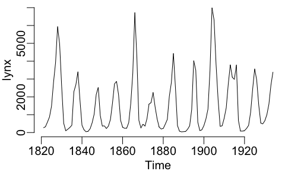

```r
data <- data.frame(year = seq(1821, 1934, by = 1), y = as.numeric(lynx))
data$x <- data$year - min(data$year)
plot(lynx)
```

Based on a visual examination of the dataset, we can observe an obvious 10-year quasi-periodic behavior in the lynx count with evolving amplitudes over time. Therefore, we will consider fitting the following sGP model:

$$\begin{aligned}
y_i|\lambda_i &\sim \text{Poisson}(\lambda_i) ,\\
\log(\lambda_i) &= \eta_i = \beta_0 + g(x_i) + \xi_i,\\
g &\sim \text{sGP} \bigg(a = \frac{2\pi}{10}, \sigma\bigg),\\
\xi_i &\sim N(0,\sigma_\xi).
\end{aligned}$$

Here, each $y_i$ represents the lynx count, $x_i$ represents the number of years since 1821, and $\xi_i$ is an observation-level random intercept to account for overdispersion effect.

## Prior Elicitation:

```r
prior_PSD <- list(u = 1, alpha = 0.01)
prior_SD <- BayesGP::prior_conversion_sgp(d = 50, prior = prior_PSD, a = 2*pi/10)
```

## Model Fitting:

To fit the sGP model with BayesGP, specify `model = "sGP"`, and then specify the frequency parameter `a` and the number of sB spline basis used to approximate `k`.

```r
mod <- model_fit(formula = y ~ f(x = year,
                                    model = "sGP",
                                    a = 2*pi/10, k = 30,
                                    sd.prior = list(prior = "exp", param = prior_SD, h = 2)) +
                               f(x = x,
                                    model = "IID",
                                    sd.prior = list(prior = "exp", param = 0.5)),

                 family = "Poisson",
                 data = data,
                 method = "aghq")
```

The fitted sGP model is presented below:

```r
summary(mod)
```

```
#> Here are some posterior/prior summaries for the parameters:
#>         name median q0.025 q0.975       prior prior:P1 prior:P2
#> 1  intercept  6.685  6.522  6.852      Normal    0.000    1e+03
#> 2 year (PSD)  0.461  0.364  0.581 Exponential    0.126    1e-02
#> 3     x (SD)  0.262  0.203  0.342 Exponential    0.500    5e-01
#> For Normal prior, P1 is its mean and P2 is its variance.
#> For Exponential prior, prior is specified as P(theta > P1) = P2.
```

We can similarly use `predict` to evaluate the effect at different locations:

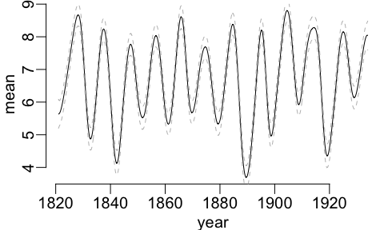

```r
pred_sGP <- predict(mod, variable = "year", newdata = data.frame(year = seq(min(data$year), max(data$year), by = 0.1)))
plot(mean ~ year, data = pred_sGP, type = 'l', col = 'black')
lines(q0.025 ~ year, data = pred_sGP, lty = 'dashed', col = 'grey')
lines(q0.975 ~ year, data = pred_sGP, lty = 'dashed', col = 'grey')
```

```r
mod <- model_fit(formula = y ~ f(x = year,
                                    model = "sGP",
                                    a = 2*pi/10, k = 30,
                                    sd.prior = list(prior = "exp", param = prior_SD, h = 2),
                                    boundary.prior = list(prec = c(Inf, Inf))) +
                               f(x = x,
                                    model = "IID",
                                    sd.prior = list(prior = "exp", param = 0.5)),

                 family = "Poisson",
                 data = data,
                 method = "aghq")
par(oldpar)
```